# Pilot Study Analysis: The Compatibility Effect between Physical Stimulus Size and Left-Right Responses

Florian Pätzold 977687, Daniel Menzel 979379, Ramon Zacharias 977316, Shari Hiltner 979694

24/07/2020

This analysis script is largely based on the internet tutorial, which you can find here: [https://www.scribbr.com/statistics/anova-in-r/].

## 0. Setting up the required packages

# 1. Load in the data.

We here laod in the raw data by our 3 participants gathered in the pilot study of our experiment (and bind them together to one data frame).

```r
# Load in the data from the pilot study
comp_pilot_1_raw <- read_csv("/Users/florian/Documents/Studium/Semester_4/Experimental Psychology Lab/Final_Project/data/pilot_1.csv")
comp_pilot_2_raw <- read_csv("/Users/florian/Documents/Studium/Semester_4/Experimental Psychology Lab/Final_Project/data/pilot_2.csv")
comp_pilot_3_raw <- read_csv("/Users/florian/Documents/Studium/Semester_4/Experimental Psychology Lab/Final_Project/data/pilot_3.csv")

# Add participant ID
comp_pilot_1_raw <- comp_pilot_1_raw %>% mutate(subject_id = rep(c(1), length(comp_pilot_1_raw$RT)))
comp_pilot_2_raw <- comp_pilot_2_raw %>% mutate(subject_id = rep(c(2), length(comp_pilot_2_raw$RT)))
comp_pilot_3_raw <- comp_pilot_3_raw %>% mutate(subject_id = rep(c(3), length(comp_pilot_3_raw$RT)))

# Bind data together
comp_pilot_raw <- rbind(comp_pilot_1_raw, comp_pilot_2_raw, comp_pilot_3_raw)
comp_pilot_raw
```

```
## # A tibble: 450 x 25
##    trial_type trial_number key_pressed correctness    RT picture key1  key2
##    <chr>             <dbl> <chr>       <chr>       <dbl> <chr>   <lgl> <chr>
##  1 practice              1 f           correct      3063 images… FALSE j
##  2 practice              2 f           correct      3123 images… FALSE j
##  3 practice              3 j           correct      2911 images… FALSE j
##  4 practice              4 f           correct      2828 images… FALSE j
##  5 practice              5 j           correct      2978 images… FALSE j
##  6 practice              6 f           correct      2927 images… FALSE j
##  7 practice              7 j           correct      2947 images… FALSE j
##  8 practice              8 j           correct      2891 images… FALSE j
##  9 practice              9 j           correct      2907 images… FALSE j
## 10 practice             10 f           correct      3041 images… FALSE j
## # … with 440 more rows, and 17 more variables: f <chr>, j <chr>,
## #   expected <chr>, Mapping <chr>, startDate <chr>, startTime <dbl>, age <dbl>,
## #   gender <chr>, handedness <chr>, education <chr>, languages <chr>,
## #   comments <chr>, endTime <dbl>, timeSpent <dbl>, experiment_id <chr>,
## #   X24 <lgl>, subject_id <dbl>
```

# 2. Processing and cleaning the data

Time to clean our data! Find the justification of the cleaning process in the preregistration of our study.

```r
# We exclude columns, that are not required for the analysis
comp_pilot_data <- comp_pilot_raw %>%
  dplyr::select(subject_id,
         trial_type,
         key_pressed,
         Mapping,
         correctness,
         RT,
         handedness, # discard data from left-handers because of H2
         timeSpent # discard data from participants, that finished experiment faster than 5min
         ) %>%
  mutate(RT = RT - 2500) %>%  # We forgot to subtract pause (1500ms) and fix_duration (1000ms) hooks in the magpie implementation of the experiment.
  rename("response" = "key_pressed") %>%
  rename("mapping" = "Mapping") %>%
  rename("time_spent" = "timeSpent") %>%
  filter(handedness == "right" & RT > 100 & RT < 1500 & time_spent > 5 & trial_type == "main" & correctness == "correct") # data exclusion (see preregistration)

# Change key name to response location
for (i in 1:length(comp_pilot_data$response)) {
  if(comp_pilot_data$response[i] == "j") {
    comp_pilot_data$response[i] <- "right"
  } else {
    comp_pilot_data$response[i] <- "left"
  }
}

comp_pilot_data
```

```
## # A tibble: 347 x 8
##    subject_id trial_type response mapping correctness    RT handedness
##         <dbl> <chr>      <chr>    <chr>   <chr>       <dbl> <chr>
##  1          1 main       left     compat… correct       600 right
##  2          1 main       left     compat… correct       449 right
##  3          1 main       right    compat… correct       468 right
##  4          1 main       right    compat… correct       499 right
##  5          1 main       left     compat… correct       452 right
##  6          1 main       right    compat… correct       436 right
##  7          1 main       left     compat… correct       565 right
##  8          1 main       right    compat… correct       340 right
##  9          1 main       right    compat… correct       475 right
## 10          1 main       right    compat… correct       581 right
## # … with 337 more rows, and 1 more variable: time_spent <dbl>
```

# 3. Visualizing the data.

To get a good idea of what our data looks like we now plot the mean reaction times for the different mapping conditions (compatible and incompatible) grouped by response locations (left and right).

```r
# Define a function for calculating the standard error
se <- function(x) sd(x) / sqrt(length(x))

# aggregate mean reaction times per subject and mapping condition
comp_pilot_agg <- comp_pilot_data %>%
  group_by(response, mapping) %>%
  summarise(mean_RT = mean(RT), se_RT = se(RT))

# the aggregated data frame
comp_pilot_agg
```

```
## # A tibble: 4 x 4
## # Groups:   response [2]
##   response mapping      mean_RT se_RT
##   <chr>    <chr>          <dbl> <dbl>
## 1 left     compatible      478.  9.82
## 2 left     incompatible    516. 15.2
## 3 right    compatible      469. 10.5
## 4 right    incompatible    492. 12.5
```

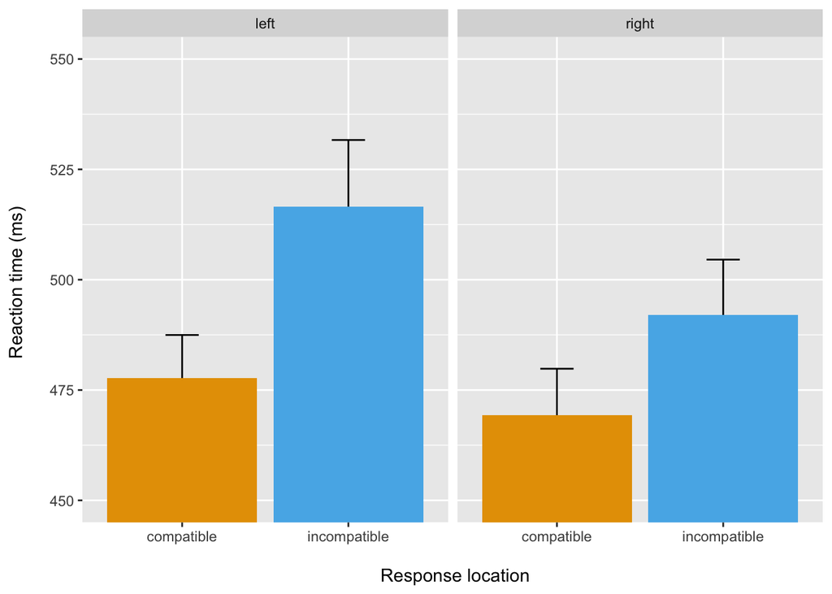

```r
comp_pilot_agg %>% ggplot(aes(x = mapping, y = mean_RT, fill = mapping)) +
  geom_errorbar(aes(ymin = mean_RT - se_RT, ymax = mean_RT + se_RT), width = 0.2) +
  geom_col() +
  ylab("Reaction time (ms) \n") +
  xlab("\n Response location") +
  facet_grid(~response) +
  coord_cartesian(ylim = c(450,550)) +
  legend_none()
```